# week2

Brad McNeney

2017-01-14

## Week 2 exercises for tutorial

## logical

1. Predict the outcome of the following:

   ```
   c(1, FALSE)
   c("a",1)
   c(list(1),"a")
   c(TRUE,1)
   ```

2. If `vv <- list(a=1,b=2)`, why doesn’t `as.vector(vv)` work to coerce `vv` into an atomic vector?

vector has atomic and list, vv itself is a list, it is a vector. as.vector will not change it.

3. What is `dim(cbind(A,A))` if `A = matrix(1:4,2,2)`?

cbind is column bind, so it is 2 rows and 4 columns.

4. What do the following return?

   ```
   TRUE | FALSE   true or false = true
   c(TRUE,TRUE) & c(FALSE,TRUE)    true and false returns false  true and true returns true
   c(TRUE,TRUE) && c(FALSE,TRUE)     only return the first element
   ```

5. Write a code chunk that (i) reads in the `gapminder` data from its package, (ii) extracts the data on Canada, the United States and Mexico, and (iii) plots life expectancy versus year for these three countries using different plotting characters for each country. Add a `loess` scatterplot smoother for each country using a span of 3/4.

```r
library(gapminder)
library(dplyr)
```

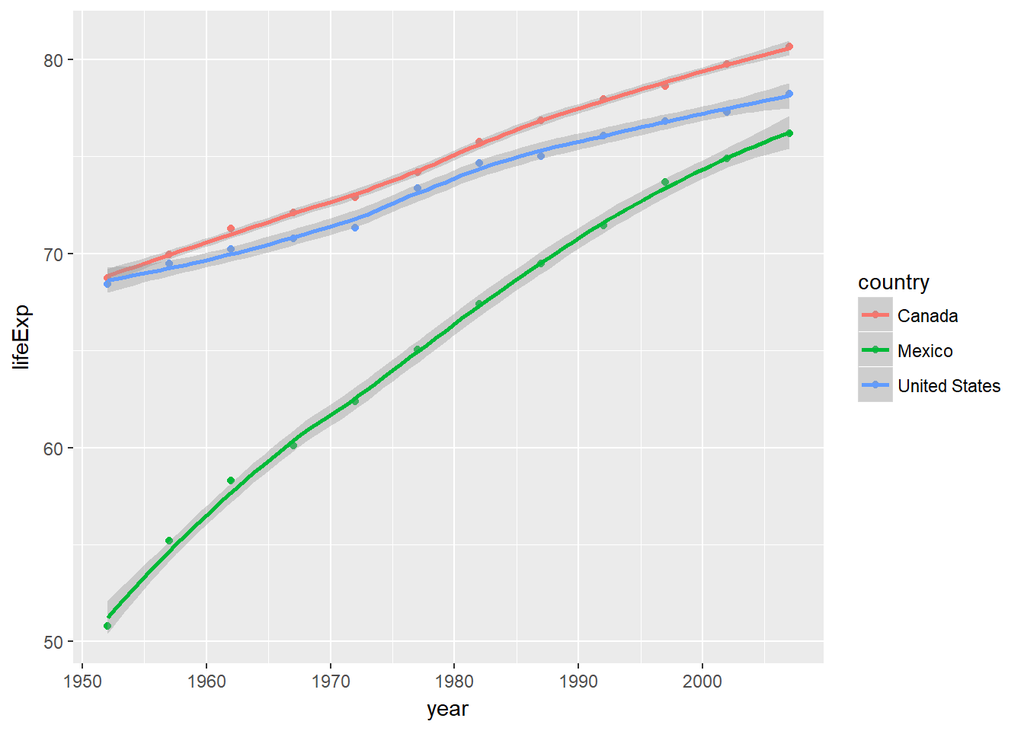

```r
library(ggplot2)
cc = c("Canada", "United States", "Mexico")
gapminder %>% filter(country %in% cc) %>%
ggplot(aes(x=year, y=lifeExp, color=country)) + geom_point() + geom_smooth(method = "loess", span = 3/4)
```

6. The following code chunk is typed into the R Console.
   - What is the output of the function call `f(5)`?
   - What is the enclosing environment of `f()`?
   - What is the enclosing environment of `g()`?
   - What search order does R use to find the value of `x` when it is needed in `g()`? ```

```r
x <- 1

f <- function(y) {
  g <- function(z) {
    (x+z)^2
  }
  g(y)
}
```

-f(5), y=z=5, x=1, (1+5)^2=36

[output not shown]